# Impacts of LOP differences on the net biodiversity effect

—————- 2D LOP experiment —————-

Elena Plekhanova

September 16, 2020

We conducted an experiment, where we wanted to investigate how LOP of two “species” contribute to the net biodiversity effect. For this, we created around 10,000 simulations, where we vary:

- LOP of 1st “species”
  - reflectance of 1st “species” from 0 to 1 with interval 0.1
  - anglesittance of 1st “species” from 0 to (1 - reflectance) with interval 0.1
- LOP of 2nd “species”

For each combination of LOP, we created the scenes of monocultures and the scene of combination of this two species.

Other parameters of simulation:

```r
library(ggplot2)
library(gridExtra)
library(gplots)
library(RColorBrewer)
library(cowplot)
library(viridis)
library(dplyr)

Nspecies = 121
Nscenes = 1
```

```r
solar_path = "./Data_for_figures/Solar_irradiance.csv"
read_solar_irradiance = function(sol_path = solar_path, bands = "all") {
  srad = read.csv(sol_path)
  srad = srad[srad$wavelength < 3,c(2:3)]
  srad$wavelength = round(srad$wavelength, 3)
  ## Pick only the irradiance between 400 and 2500 nm at 50nm range
  srad = srad[unlist(sapply(c(8:50)/20, function(i) which(abs(srad$wavelength-i)==min(abs(srad$wavelength-i))))),]
  srad = aggregate(srad, by = list(srad$wavelength), FUN = "mean")[,c(2:3)]
  if (bands == "VIS") {

  srad$irradiance = srad$irradiance/sum(srad$irradiance[1:7])
  srad$irradiance[8:43] = 0

  } else srad$irradiance = srad$irradiance/sum(srad$irradiance)

  return(srad$irradiance)
}
solar_irradiance = read_solar_irradiance(bands = "all")
```

```r
dat = read.csv(
    paste0("./Data_for_figures/Fig5_2trees/profiles_2d_angles.csv"))
dat$num_of_species = as.factor(dat$num_of_species)
dat$abs_mean = dat$abs_mean*solar_irradiance[dat$band]
dat = aggregate(abs_mean ~ height_m + pos + angles + angles2 + num_of_species + species + idSimulation,
                   data = dat, FUN = "sum")

## Correct ordering of angles2
mas2 = read.csv("./Data_for_figures/Fig5_2trees/P_fileName1_angles2.csv", stringsAsFactors = F)
colnames(mas2) = c("id", "txt")

mas2$txt = sapply(mas2$txt, function(x) substr(x, 1, nchar(x) - 4))
mas2$txt = as.numeric(mas2$txt)

mas2 = mas2[mas2$id %in% unique(dat$angles2),]



dat$angles2 = as.factor(dat$angles2)
levels(dat$angles2)
```

```
 [1] "1"  "12" "13" "14" "15" "16" "17" "18" "19" "20" "21"
```

```r
levels(dat$angles2) = mas2$id[match(mas2$id, mas2$id[order(mas2$txt, decreasing = T)])]
dat$angles2 = as.numeric(as.character(dat$angles2))
levels(as.factor(dat$angles2))
```

```
 [1] "1"  "12" "13" "14" "15" "16" "17" "18" "19" "20" "21"
```

```r
dat$angles[dat$angles == 1] = 11
dat$angles2[dat$angles2 == 1] = 11

dat$angles = 0.1*(dat$angles - 11)
dat$angles2 = 0.1*(dat$angles2 - 11)

#dat$species = as.factor(dat$species)
#levels(dat$species) = c("specie1", "specie2")

#dat$angles_refl[dat$species == 0] = paste0(dat$angles[dat$species == 0], "_", dat$refl1[dat$species == 0])
#dat$angles_refl[dat$species == 1] = paste0(dat$angles2[dat$species == 1], "_", dat$refl2[dat$species == 1])
dat$species[dat$species == 0] = paste0(dat$angles[dat$species == 0], "_")
dat$species[dat$species == 1] = paste0(dat$angles2[dat$species == 1], "_")



subdat_crown = as.data.frame(dat[dat$height_m != 1,])
```

```r
unique(dat$angles2)
```

```
 [1] 0.0 0.1 0.2 0.3 0.4 0.5 0.6 0.7 0.8 0.9 1.0
```

```r
subdat_crown$pos = subdat_crown$idSimulation
aggdat = aggregate(abs_mean ~ height_m + pos + angles + angles2 + num_of_species,
                   data = subdat_crown, FUN = "mean")
aggdat = aggregate(abs_mean ~  pos + angles + angles2 + num_of_species,
                   data = aggdat, FUN = "sum")

res_tab = lapply(unique(aggdat$pos[as.numeric(aggdat$num_of_species) > 1]), function(POS) {

  av_mixture = subset(aggdat, pos == POS, abs_mean)

  abs_of_monocultures = lapply(unique(subdat_crown$species[subdat_crown$pos == POS]), function(x) {
    position_of_mon = subdat_crown$pos[subdat_crown$species == x &
                                         subdat_crown$num_of_species == 1][1]
    res = subset(aggdat, pos == position_of_mon, select = abs_mean)
    return(res)
  })

  av_monocultures = apply(do.call(rbind.data.frame, list(abs_of_monocultures)), 1, mean)

  one_mix = data.frame( ( sapply( c(1:nrow(av_mixture)), function(i) (av_mixture[i,1] - av_monocultures[i])*100/av_monocultures[i] ) ), c(1:nrow(av_mixture)),
                        rep(POS, nrow(av_mixture)))
  colnames(one_mix) = c("abs_mean", "height_m", "pos")

  one_mix$diff_sum = rep(round(sum(one_mix$abs_mean), 7), nrow(one_mix))
  one_mix$num_of_species = rep(aggdat$num_of_species[aggdat$pos == POS][1], nrow(one_mix))
  one_mix$angles = rep(aggdat$angles[aggdat$pos == POS][1], nrow(one_mix))
  one_mix$angles2 = rep(aggdat$angles2[aggdat$pos == POS][1], nrow(one_mix))

  return(one_mix)
})
res_tab = do.call(rbind.data.frame, res_tab)
```

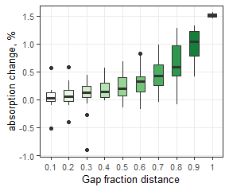

```r
aggdat = aggregate(diff_sum ~ pos + angles + angles2,
                   data = res_tab, FUN = "mean")
aggdat$diff_angles = abs(aggdat$angles - aggdat$angles2)
aggdat = aggdat[aggdat$diff_angles != 0,]
aggdat$diff_angles = as.factor(aggdat$diff_angles)

my_palette = brewer.pal(9,"Greens")
#my_palette = c("white", "#1B9E77")
my_palette=colorRampPalette(my_palette)(11)
mt = aggdat %>% mutate(diff_angles = diff_angles) %>%
  group_by(diff_angles) %>%
  mutate(med_diffsum = median(diff_sum))
ggplot(mt, aes(diff_angles, diff_sum, group = diff_angles, fill = as.factor(med_diffsum))) +       geom_boxplot(width=0.5, alpha = 1, size = 0.65) +
  scale_fill_manual(values = my_palette) +
  xlab("Gap fraction distance") + ylab("absorption change, %") + theme_bw() +
  theme(panel.grid.minor.y = element_blank(),
        plot.title = element_text(size=12, hjust = 0.5),
        axis.title.x = element_text(size=10), axis.text.x  = element_text(size=8),
        axis.title.y = element_text(size=10), axis.text.y  = element_text(size=8),
        legend.position = "none")
```

## Without vertical LAD

```r
subdat_crown$pos = subdat_crown$idSimulation
aggdat = aggregate(abs_mean ~ height_m + pos + angles + angles2 + num_of_species,
                   data = subdat_crown, FUN = "mean")
aggdat = aggregate(abs_mean ~ pos + angles + angles2 + num_of_species,
                   data = aggdat, FUN = "sum")



res_tab = lapply(unique(aggdat$pos[as.numeric(aggdat$num_of_species) > 1]), function(POS) {

  av_mixture = subset(aggdat, pos == POS, abs_mean)

  abs_of_monocultures = lapply(unique(subdat_crown$species[subdat_crown$pos == POS]), function(x) {
    position_of_mon = subdat_crown$pos[subdat_crown$species == x &
                                         subdat_crown$num_of_species == 1][1]
    res = subset(aggdat, pos == position_of_mon, select = abs_mean)
    return(res)
  })

  av_monocultures = apply(do.call(rbind.data.frame, list(abs_of_monocultures)), 1, mean)

  one_mix = data.frame( ( sapply( c(1:nrow(av_mixture)), function(i) (av_mixture[i,1] - av_monocultures[i])*100/av_monocultures[i] ) ), c(1:nrow(av_mixture)),
                        rep(POS, nrow(av_mixture)))
  colnames(one_mix) = c("abs_mean", "height_m", "pos")

  one_mix$diff_sum = rep(round(sum(one_mix$abs_mean), 7), nrow(one_mix))
  one_mix$num_of_species = rep(aggdat$num_of_species[aggdat$pos == POS][1], nrow(one_mix))
  one_mix$angles = rep(aggdat$angles[aggdat$pos == POS][1], nrow(one_mix))
  one_mix$angles2 = rep(aggdat$angles2[aggdat$pos == POS][1], nrow(one_mix))

  return(one_mix)
})
res_tab = do.call(rbind.data.frame, res_tab)
```

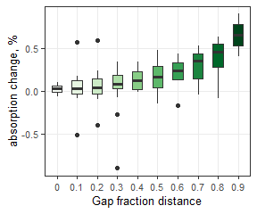

```r
aggdat = aggregate(diff_sum ~ pos + angles + angles2,
                   data = res_tab, FUN = "mean")
aggdat = aggdat[(aggdat$angles!= 0.0) & (aggdat$angles2!= 0.0),]

aggdat$diff_angles = abs(aggdat$angles - aggdat$angles2)
aggdat$diff_angles = as.factor(aggdat$diff_angles)
my_palette = brewer.pal(9,"Greens")
#my_palette = c("white", "#1B9E77")
my_palette=colorRampPalette(my_palette)(10)
mt = aggdat %>% mutate(diff_angles = diff_angles) %>%
  group_by(diff_angles) %>%
  mutate(med_diffsum = median(diff_sum))
ggplot(mt, aes(diff_angles, diff_sum, group = diff_angles, fill = as.factor(med_diffsum))) +       geom_boxplot(width=0.5, alpha = 1, size = 0.65) +
  scale_fill_manual(values = my_palette) +
  xlab("Gap fraction distance") + ylab("absorption change, %") + theme_bw() +
  theme(panel.grid.minor.y = element_blank(),
        plot.title = element_text(size=12, hjust = 0.5),
        axis.title.x = element_text(size=10), axis.text.x  = element_text(size=8),
        axis.title.y = element_text(size=10), axis.text.y  = element_text(size=8),
        legend.position = "none")
```

## What combination of leaf optical properties contributes to this difference?

H0: $abs_{mix-mon}$ mainly dependant on difference between absorptances of 2 species and their anglesittances.

To check if this sentance holds for our simulations, we represented difference between mixtures and monocultures in corresponding axes:

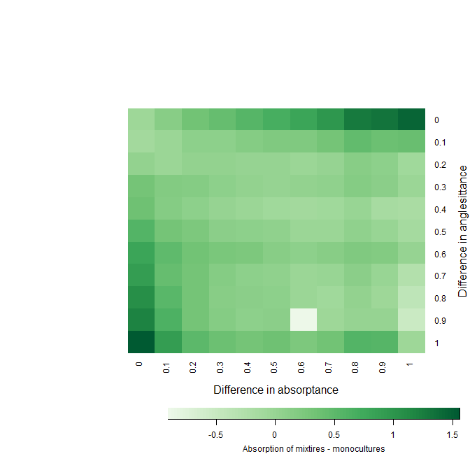

```r
aggdat = aggregate(diff_sum ~ pos + angles + angles2,
                   data = res_tab, FUN = "mean")
aggdat$sp1 =  round( abs(aggdat$angles) , 2)
#aggdat$sp1 =  round( abs(aggdat$refl1 - aggdat$refl2) , 2)
aggdat$sp2 =  round( abs(aggdat$angles2) , 2)

vector_a = aggdat$sp1
vector_b = aggdat$sp2

albmat = sapply(sort(unique(vector_a)), function (a)
  sapply(sort(unique(vector_b)), function(b)
    mean( aggdat$diff_sum[vector_a == a & vector_b== b])))

my_palette = brewer.pal(7,"Greens")
my_palette=colorRampPalette(my_palette)(100)

lmat = rbind(c(0,3),c(2,1),c(0,4))
lwid = c(1.5,4)
lhei = c(1.5,4,1)


heatmap.2(t(albmat),margins=c(5,5), scale="none", labCol = sort(unique(vector_b)),
          labRow = sort(unique(vector_a)),
          dendrogram="none",  trace="none", xlab = "Difference in absorptance", key.title = NA, keysize = 1,
          lmat = lmat, lwid = lwid, lhei = lhei,
          key.xlab = "Absorption of mixtires - monocultures",
          ylab = "Difference in anglesittance", density.info="none", Colv = NA, Rowv = NA,
          col = my_palette, symm=F,symkey=F,symbreaks=F)
```

```r
library(plotly)
p <- plot_ly(z = ~t(albmat)) %>% add_surface() %>%
  layout(
    title = "Difference in absorptance between mixtures and monocultures",
    scene = list(
      xaxis = list(title = "Difference in absorption"),
      yaxis = list(title = "Difference in anglesittance"),
      zaxis = list(title = "Difference")
    ))
#p
```

On natural background

## Optional

```r
brewer.pal(n = 8, name = "Dark2")
```

```
[1] "#1B9E77" "#D95F02" "#7570B3" "#E7298A" "#66A61E" "#E6AB02" "#A6761D" "#666666"
```

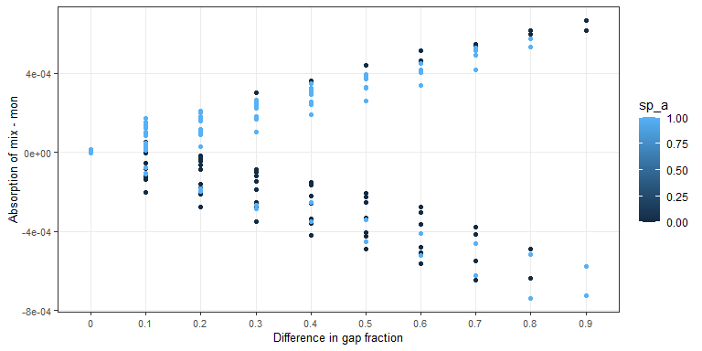

```r
aggdat = aggregate(abs_mean ~ height_m + pos + angles + angles2 + num_of_species + species,
                   data = subdat_crown, FUN = "mean")
res_tab = lapply(unique(aggdat$pos[as.numeric(aggdat$num_of_species) > 1]), function(POS) {

      av_mix = subset(aggdat, pos == POS)
      sps = unique(av_mix$species)
      av_mix_sp1 = av_mix$abs_mean[av_mix$species == sps[1]]
      av_mix_sp2 = av_mix$abs_mean[av_mix$species == sps[2]]
      av_mon_sp1 = subset(aggdat, species == sps[1] &  num_of_species == 1)$abs_mean
      av_mon_sp2 = subset(aggdat, species == sps[2] &  num_of_species == 1)$abs_mean

      one_mix = data.frame(cbind(c((av_mix_sp1 - av_mon_sp1)[1], (av_mix_sp2 - av_mon_sp2)[1]),
                                 c(av_mon_sp1, av_mon_sp2),
                                 c(1, 0),
                                 rep(POS, 2) ))

      colnames(one_mix) = c("abs_mean", "mon_abs", "sp_a" ,"pos")
      one_mix$diff_mon = (av_mon_sp1 - av_mon_sp2)[1] ## difference in absorbtion of monocultures
      one_mix$diff_mix = (av_mix_sp1 - av_mix_sp2)[1] ## difference in absorbtion of mixtures
      one_mix$gain_mix = (av_mix_sp1 - av_mon_sp1)[1] + (av_mix_sp2 - av_mon_sp2)[1] ## difference in absorbtion of mixtures
      one_mix$species = sps
      one_mix$angles = av_mix$angles
      one_mix$angles2 = av_mix$angles2
      one_mix$name_species = paste0(sps[1], " + ", sps[2])

      return(one_mix)
    })

res_tab = do.call(rbind.data.frame, res_tab)

aggdat = aggregate(abs_mean ~ pos + angles + angles2 + sp_a,
                   data = res_tab, FUN = "mean")
aggdat$maxangle = as.factor(sapply(c(1:nrow(aggdat)), function(i) max(aggdat$angles[i], aggdat$angles2[i])))

aggdat$diff_angles = abs(aggdat$angles - aggdat$angles2)
aggdat$diff_angles = as.factor(aggdat$diff_angles)
my_palette = brewer.pal(9,"Greens")
my_palette=colorRampPalette(my_palette)(10)
mt = aggdat %>% mutate(diff_angles = diff_angles) %>%
  group_by(diff_angles) %>%
  mutate(med_diffsum = median(abs_mean))
ggplot(mt, aes(diff_angles, abs_mean, group = diff_angles, col = sp_a)) + geom_point() +
  xlab("Difference in gap fraction") + ylab("Absorption of mix - mon") + theme_bw() +
  theme(panel.grid.minor.y = element_blank(),
        plot.title = element_text(size=12, hjust = 0.5),
        axis.title.x = element_text(size=10), axis.text.x  = element_text(size=8),
        axis.title.y = element_text(size=10), axis.text.y  = element_text(size=8))
```

```r
aggdat$maxangle = as.factor(sapply(c(1:nrow(aggdat)), function(i) max(aggdat$angles[i], aggdat$angles2[i])))

aggdat2 = aggregate(diff_sum ~ diff_angles + maxangle,
                   data = aggdat, FUN = "mean")
```

```
Error in eval(predvars, data, env) : object 'diff_sum' not found
```

```r
heatmap.2(t(albmat),margins=c(7,7), scale="none", labCol = sort(unique(vector_b)),
          labRow = sort(unique(vector_a)),
          dendrogram="none",  trace="none", xlab = "Difference in absorption", key.title = NA, keysize = 1,
          lmat = lmat, lwid = lwid, lhei = lhei,
          cexRow = 1.8, cexCol = 1.8,
          key.xlab = "FAPAR change", par = par(cex.lab = 1.8, cex.axis = 1.8),
          ylab = "Difference in anglesittance", density.info="none", Colv = NA, Rowv = NA,
          col = my_palette, symm=F,symkey=F,symbreaks=F)
par(cex.lab = 18)
```

[output not shown]

Although the most of variation indeed explained by these axes, we can see some non-linearity in this plot, which has not been explained yet.